# SAIS-Copy1

## SAIS Survey Questions:

- General info
- Nationality
- Gender
- Age
- Job Status

*Closed Questions*

**Sec1**

- P1: يعد السـب والشـتـم عـبر الانـتـرنـت أحد أنواع الجرائم المعلوماتية ويعرض منتهكها للعقوبة
- P2: يعد التنصت كمشاهدة البيانات أو اعتراض البيانات عبر الشبكة المعلوماتية أو أحد أجهزة الحاسب أحد أنواع الجرائم المعلوماتية ويعرض منتهكها للعقوبة
- P3: لا يجوز معالجة البيانات الشخصية للمستخدم دون موافقتهم الصريحة على ذلك
- P4: يحظر على أي موظف ـ ولو بعد انتهاء خدمته ـ نشر أي وثيقة سرية أو إفشاء أي معلومة سرية حصل عليها أو عرفها بحكم وظيفته وكان نشرها أو إفشاؤها لا يزالان محظورين
- P5: يحظر إخراج الوثائق السرية من الجهات الحكومية، أو تبادلها مع الغير بأي وسيلة كانت، أو الاحتفاظ بها في غير الأماكن المخصصة لحفظها، وتحظر طباعتها أو نسخها أو تصويرها خارج الجهات الحكومية؛ إلا وفق ضوابط يصدرها المركز الوطني للوثائق والمحفوظات
- P6: يجب أن تغطي متطلبات الأمن السيبراني المتعلقة بـإدارة هويات الدخول والصلاحيات في الجهة بحد أدنى (التحقق من هوية المستخدم عبر تسجيل الدخول وكلمات المرور - إدارة تصاريح وصلاحيات المستخدمين - إدارة الصلاحيات الهامة والحساسة - المراجعة الدورية لهويات الدخول والصلاحيات)
- P7: يجب تطوير واعتماد برنامج للتوعية بالأمن السيبراني في جميع الجهات من خلال قنوات متعددة دورياً، وذلك لتعزيز الوعي بالأمن السيبراني وتهديداته ومخاطره، وبناء ثقافة إيجابية للأمن السيبراني
- P8: لا يجوز المساس بالحياة الخاصة عن طريق إساءة استخدام الأجهزة النقالة المزودة بكاميرا، ويعرض الفاعل للعقوبة
- P9: لا يجوز التشهير بالآخرين، وإلحاق الضرر بهم، عبر وسائل تقنيات المعلومات المختلفة ويعرض الفاعل للعقوبة
- P10: تصوير الهوية الوطنية مخالف، يتم فقط الاطلاع عليها و تدوين البيانات وإعادتها لحاملها
- P11: يجب على الجهات جمع البيانات اللازمة لاستكمال العمل بأدنى حد ممكن والاحتفاظ بها لمدة محدودة والتخلص منها بعد تحقيق الغرض منها، حيث أن الاحتفاظ بها يعد انتهاكاً للخصوصية
- P12: توجد سياسات لأنظمة أمن معلومات في جميع الجهات بما فيها الشركات ، الجامعات، البنوك
- P13: يجب ضمان حماية الأنظمة وأجهزة معالجة المعلومات بما في ذلك أجهزة المستخدمين والبنى التحتية للجهة من المخاطر السيبرانية / الإلكترونية
- P14: يجب ضمان حماية البريد الإلكتروني للجهة من المخاطر السيبرانية والتأكد من عملية حماية و تصفية البريد من الرسائل مجهولة المصدر، خصوصاً رسائل التصيد والاقتحام، باستخدام تقنيات وآليات الحماية الحديثة والمتقدمة
- P15: يجب التأكد من أمان الاتصال بالإنترنت والمتصفح، ويشمل ذلك التقييد الحازم للمواقع الالكترونية المشبوهة،ومواقع مشاركة وتخزين الملفات
- P16: يجب ضمان حماية بيانات ومعلومات الجهة والاعدادات التقنية للأنظمة والتطبيقات الخاصة من الأضرار الناجمة عن المخاطر السيبرانية، عن طريق النسخ الاحتياطي للمعلومات بشكل دوري و أمن
- P17: يجب ضمان حماية الأصول المعلوماتية والتقنية للجهة من الوصول المادي غير المصرح به والفقدان والسرقة والتخريب
- P18: عند التعرض لأحد الهجمات المعلوماتية أو السيبرانية، يتم ابلاغ الجهات المختصة مثل ( كلنا آمن - هيئة الاتصالات وتقنية المعلومات - تطبيق ترشيح السعودية)

*P : Policies Questions Answer catigrized as following:*

- 1 = Not Aware
- 2 = Aware but not following the policy
- 3 = Aware and follow the policy

**Sec2**

- A1: أنظمة أمن المعلومات واضحة بالنسبة لي ويتم التذكير والتوعية بها بشكل دوري
- A2: إذا تم تنسيق محاضرات أو دورات للتوعية بأمن المعلومات أنا أهتم بحضورها
- A3: عندما يتم ارسال أي تعليمات أو تحديثات بخصوص أنظمة المعلومات أو سياسة استخدام موقع أنا أهتم بقراءتها وتطبيقها
- A4: أهتم بتعليم عائلتي الأنظمة ومدى أهميتها
- A5: أحاول الاطلاع على تحديثات أنظمة المعلومات

*A : Answers:*

- Yes - No

*Open Question*

- External Analysis: اقتراحاتك لتطوير و تحسين وعي المجتمع بنظام أمن المعلومات

```python
import pandas as pd
import numpy as np
import matplotlib.pyplot as plt
%matplotlib inline
import seaborn as sns
plt.rcParams['figure.figsize'] = (10, 5)
plt.rcParams['font.family'] = "serif"
```

```python
SAIS= pd.read_csv('C:/Users/Butte/Downloads/SAIS.csv', delimiter=',', low_memory=False)
SAIS.head()
```

|  | Nationality | Gender | Age | Job_Status | P1 | P2 | P3 | P4 | P5 | P6 | ... | P14 | P15 | P16 | P17 | P18 | A1 | A2 | A3 | A4 | A5 |
| --- | --- | --- | --- | --- | --- | --- | --- | --- | --- | --- | --- | --- | --- | --- | --- | --- | --- | --- | --- | --- | --- |
| 0 | Saudi | Female | 26 - 35 | Employee | Aware & Follow | Aware & Follow | Aware & Follow | Aware & Follow | Aware & Follow | Aware & Follow | ... | Aware & Follow | Aware & Follow | Aware & Follow | Aware & Follow | Aware & Follow | Yes | Yes | Yes | Yes | Yes |
| 1 | Saudi | Female | 26 - 35 | Student | Aware & Follow | Aware & Follow | Aware & Follow | Aware & Follow | Aware & Follow | Aware & Follow | ... | Aware & Follow | Aware & Follow | Aware & Follow | Aware & Follow | Aware & Follow | Yes | Yes | No | Yes | Yes |
| 2 | Saudi | Female | 26 - 35 | Employee | Aware & Unfollow | Unaware | Aware & Follow | Aware & Follow | Aware & Follow | Unaware | ... | Aware & Unfollow | Aware & Unfollow | Aware & Follow | Aware & Follow | Aware & Unfollow | Yes | No | No | No | No |
| 3 | Saudi | Male | 46 - 60 | Employee | Aware & Follow | Aware & Follow | Aware & Follow | Aware & Follow | Aware & Follow | Aware & Follow | ... | Aware & Follow | Aware & Follow | Aware & Follow | Aware & Follow | Aware & Follow | Yes | Yes | Yes | Yes | Yes |
| 4 | Saudi | Female | 26 - 35 | Other | Aware & Follow | Aware & Follow | Aware & Follow | Aware & Follow | Aware & Follow | Aware & Follow | ... | Aware & Follow | Aware & Follow | Aware & Follow | Aware & Follow | Aware & Follow | No | No | No | Yes | No |

5 rows × 27 columns

```python
#No. Responses
len(SAIS)
```

```
143
```

# Overview Analysis:

```python
Questions = {'Questions':['P1 : Insulting people via internet is a type of information crimes.',
               'P2 : Snooping, viewing, and intercepting data via network are information crimes.',
                'P3 : Data can not be used without owner permission.',
                'P4 : Employee is not allowd to share any confidintial document even if he/she quit the job without permission.',
                'P5 : Employee should not keep or print any papers outside the workplace unless follow the National Center for Archive.',
                'P6 : The orgnizations must control and manage the system accessibility authorization by using (passwords- control critical and sisitive data access permission - review the access report periodically)',
                'P7 : Orgnizations must iniciate a proper cyber security enviroment aware ,and motivate thier employees to follow it.',
                'P8 : Preacing others privacy or harshing them using mobile cameras are not allowed.',
                'P9 : People defamation using mobile cameras are not allowed, and lead to legal liability.',
                'P10 : Taking photos or copies of the national ID card is not allowed, the needed data should be recorded after that the card must be returned immediately.',
                'P11: Companies must record the required data only, keeping data for long is not allowed unless it still in use and needed.',
                'P12: There are information policies in all sectors including companies, banks, and universities.',
                'P13: Orgnizations must ensure information systems and assets security including users and infastructurs from cyperattacks.'
                         ]}
Questions=pd.DataFrame(data=Questions)
```

```python
SAIS.describe().T
```

|  | count | unique | top | freq |
| --- | --- | --- | --- | --- |
| Nationality | 143 | 3 | Saudi | 140 |
| Gender | 143 | 2 | Female | 73 |
| Age | 143 | 4 | 46 - 60 | 45 |
| Job_Status | 143 | 3 | Employee | 61 |
| P1 | 143 | 3 | Aware & Follow | 128 |
| P2 | 143 | 3 | Aware & Follow | 127 |
| P3 | 143 | 3 | Aware & Follow | 117 |
| P4 | 143 | 3 | Aware & Follow | 127 |
| P5 | 143 | 3 | Aware & Follow | 130 |
| P6 | 143 | 3 | Aware & Follow | 109 |
| P7 | 143 | 3 | Aware & Follow | 105 |
| P8 | 143 | 2 | Aware & Follow | 132 |
| P9 | 143 | 3 | Aware & Follow | 130 |
| P10 | 143 | 3 | Aware & Follow | 102 |
| P11 | 143 | 3 | Aware & Follow | 96 |
| P12 | 143 | 3 | Aware & Follow | 115 |
| P13 | 143 | 3 | Aware & Follow | 119 |
| P14 | 143 | 3 | Aware & Follow | 113 |
| P15 | 143 | 3 | Aware & Follow | 115 |
| P16 | 143 | 3 | Aware & Follow | 105 |
| P17 | 143 | 3 | Aware & Follow | 117 |
| P18 | 143 | 3 | Aware & Follow | 113 |
| A1 | 143 | 2 | Yes | 106 |
| A2 | 143 | 2 | Yes | 88 |
| A3 | 143 | 2 | Yes | 103 |
| A4 | 143 | 2 | Yes | 112 |
| A5 | 143 | 2 | Yes | 83 |

```python
def categorical_summarized(dataframe, x=None, y=None, hue=None, palette="Set2", verbose=True):
    '''
    Helper function that gives a quick summary of a given column of categorical data
    Arguments
    =========
    dataframe: pandas dataframe
    x: str. horizontal axis to plot the labels of categorical data, y would be the count
    y: str. vertical axis to plot the labels of categorical data, x would be the count
    hue: str. if you want to compare it another variable (usually the target variable)
    palette: array-like. Colour of the plot
    Returns
    =======
    Quick Stats of the data and also the count plot
    '''
    if x == None:
        column_interested = y
    else:
        column_interested = x
    series = dataframe[column_interested]
    print(series.describe())
    print('mode: ', series.mode())
    if verbose:
        print('='*80)
        print(series.value_counts())

    sns.countplot(x=x, y=y, hue=hue, data=dataframe, palette=palette)
    plt.show()
```

```
count          143
unique           3
top       Employee
freq            61
Name: Job_Status, dtype: object
mode:  0    Employee
dtype: object
================================================================================
Employee    61
Other       51
Student     31
Name: Job_Status, dtype: int64
```

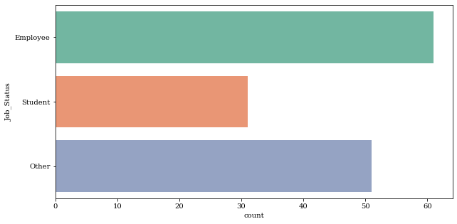

```python
categorical_summarized(SAIS, y = 'Job_Status')
```

```
count        143
unique         2
top       Female
freq          73
Name: Gender, dtype: object
mode:  0    Female
dtype: object
================================================================================
Female    73
Male      70
Name: Gender, dtype: int64
```

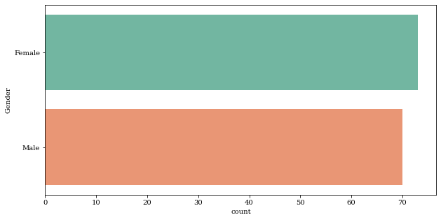

```python
categorical_summarized(SAIS, y = 'Gender')
```

```
count         143
unique          4
top       46 - 60
freq           45
Name: Age, dtype: object
mode:  0    46 - 60
dtype: object
================================================================================
46 - 60    45
26 - 35    43
18 - 25    32
36 - 45    23
Name: Age, dtype: int64
```

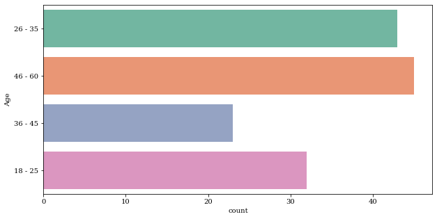

```python
categorical_summarized(SAIS, y = 'Age')
```

```python
byjobgender= SAIS.groupby(['Job_Status','Gender'])
```

```
count       143
unique        3
top       Saudi
freq        140
Name: Nationality, dtype: object
mode:  0    Saudi
dtype: object
================================================================================
Saudi        140
Resident       2
Non Saudi      1
Name: Nationality, dtype: int64
```

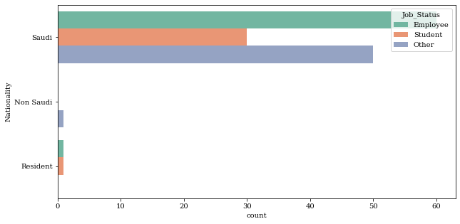

```python
categorical_summarized(SAIS, y = 'Nationality', hue='Job_Status')
```

```python
byjobgender['Age'].describe().T
```

| Job_Status Gender | Employee Female | Employee Male | Other Female | Other Male | Student Female | Student Male |
| --- | --- | --- | --- | --- | --- | --- |
| count | 22 | 39 | 33 | 18 | 18 | 13 |
| unique | 4 | 4 | 4 | 2 | 3 | 2 |
| top | 26 - 35 | 46 - 60 | 26 - 35 | 46 - 60 | 18 - 25 | 18 - 25 |
| freq | 12 | 20 | 15 | 16 | 10 | 11 |

```
count          143
unique           3
top       Employee
freq            61
Name: Job_Status, dtype: object
mode:  0    Employee
dtype: object
================================================================================
Employee    61
Other       51
Student     31
Name: Job_Status, dtype: int64
```

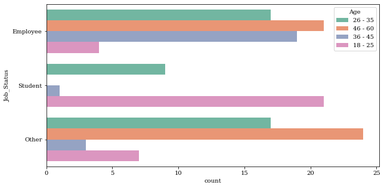

```python
categorical_summarized(SAIS, y = 'Job_Status', hue='Age')
```

```python
byjobgender['Age'].count()
```

```
Job_Status  Gender
Employee    Female    22
            Male      39
Other       Female    33
            Male      18
Student     Female    18
            Male      13
Name: Age, dtype: int64
```

```
count          143
unique           3
top       Employee
freq            61
Name: Job_Status, dtype: object
mode:  0    Employee
dtype: object
================================================================================
Employee    61
Other       51
Student     31
Name: Job_Status, dtype: int64
```

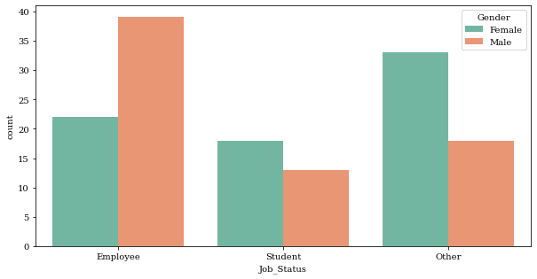

```python
categorical_summarized(SAIS, x = 'Job_Status', hue='Gender')
```

```
count          143
unique           3
top       Employee
freq            61
Name: Job_Status, dtype: object
mode:  0    Employee
dtype: object
================================================================================
Employee    61
Other       51
Student     31
Name: Job_Status, dtype: int64
```

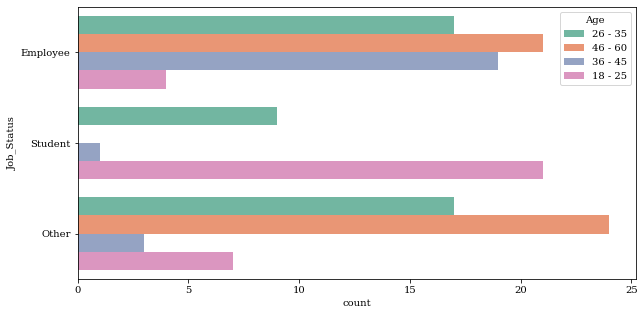

```python
categorical_summarized(SAIS, y = 'Job_Status', hue='Age')
```

```
count          143
unique           3
top       Employee
freq            61
Name: Job_Status, dtype: object
mode:  0    Employee
dtype: object
================================================================================
Employee    61
Other       51
Student     31
Name: Job_Status, dtype: int64
```

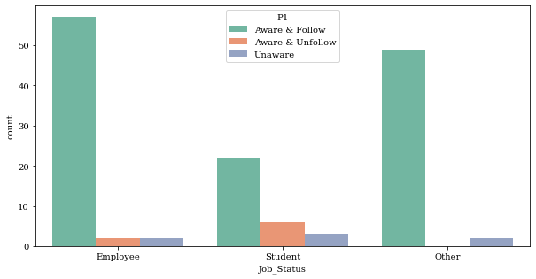

```python
categorical_summarized(SAIS, x = 'Job_Status', hue='P1')
```

```
count          143
unique           3
top       Employee
freq            61
Name: Job_Status, dtype: object
mode:  0    Employee
dtype: object
================================================================================
Employee    61
Other       51
Student     31
Name: Job_Status, dtype: int64
```

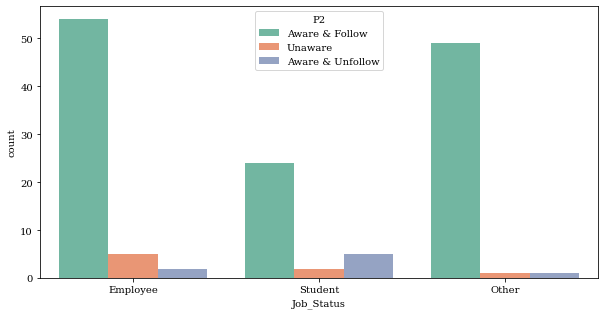

```python
categorical_summarized(SAIS, x = 'Job_Status', hue='P2')
```

```
count        143
unique         2
top       Female
freq          73
Name: Gender, dtype: object
mode:  0    Female
dtype: object
================================================================================
Female    73
Male      70
Name: Gender, dtype: int64
```

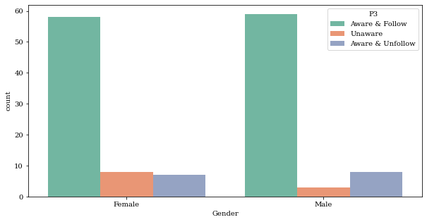

```python
categorical_summarized(SAIS, x = 'Gender', hue='P3')
```

```
count          143
unique           3
top       Employee
freq            61
Name: Job_Status, dtype: object
mode:  0    Employee
dtype: object
================================================================================
Employee    61
Other       51
Student     31
Name: Job_Status, dtype: int64
```

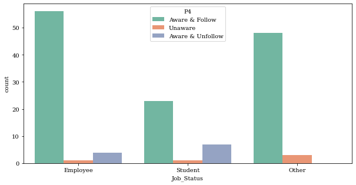

```python
categorical_summarized(SAIS, x = 'Job_Status', hue='P4')
```

```
count          143
unique           3
top       Employee
freq            61
Name: Job_Status, dtype: object
mode:  0    Employee
dtype: object
================================================================================
Employee    61
Other       51
Student     31
Name: Job_Status, dtype: int64
```

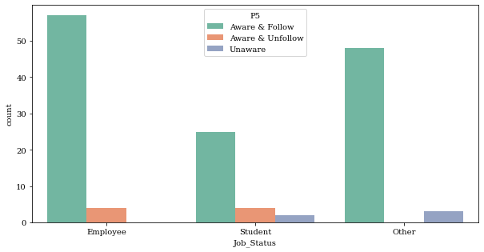

```python
categorical_summarized(SAIS, x = 'Job_Status', hue='P5')
```

```
count          143
unique           3
top       Employee
freq            61
Name: Job_Status, dtype: object
mode:  0    Employee
dtype: object
================================================================================
Employee    61
Other       51
Student     31
Name: Job_Status, dtype: int64
```

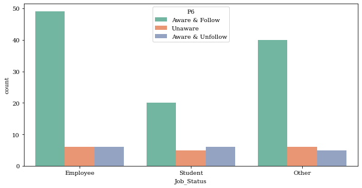

```python
categorical_summarized(SAIS, x = 'Job_Status', hue='P6')
```

```
count          143
unique           3
top       Employee
freq            61
Name: Job_Status, dtype: object
mode:  0    Employee
dtype: object
================================================================================
Employee    61
Other       51
Student     31
Name: Job_Status, dtype: int64
```

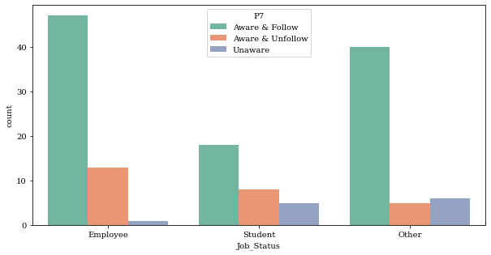

```python
categorical_summarized(SAIS, x = 'Job_Status', hue='P7')
```

```
count        143
unique         2
top       Female
freq          73
Name: Gender, dtype: object
mode:  0    Female
dtype: object
================================================================================
Female    73
Male      70
Name: Gender, dtype: int64
```

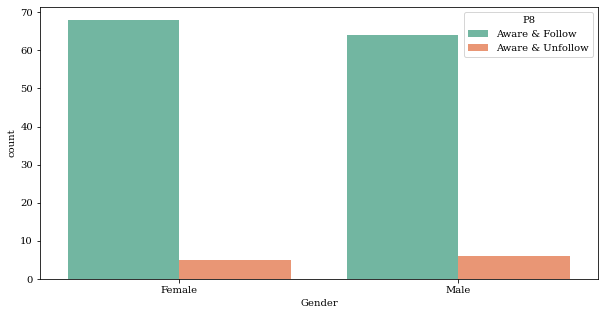

```python
categorical_summarized(SAIS, x = 'Gender', hue='P8')
```

```
count        143
unique         2
top       Female
freq          73
Name: Gender, dtype: object
mode:  0    Female
dtype: object
================================================================================
Female    73
Male      70
Name: Gender, dtype: int64
```

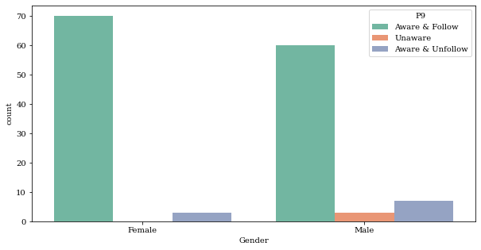

```python
categorical_summarized(SAIS, x = 'Gender', hue='P9')
```

```
count        143
unique         2
top       Female
freq          73
Name: Gender, dtype: object
mode:  0    Female
dtype: object
================================================================================
Female    73
Male      70
Name: Gender, dtype: int64
```

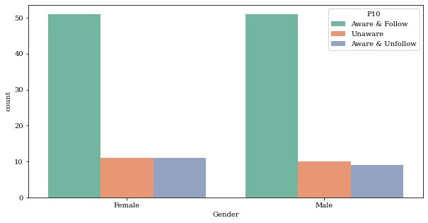

```python
categorical_summarized(SAIS, x = 'Gender', hue='P10')
```

```
count          143
unique           3
top       Employee
freq            61
Name: Job_Status, dtype: object
mode:  0    Employee
dtype: object
================================================================================
Employee    61
Other       51
Student     31
Name: Job_Status, dtype: int64
```

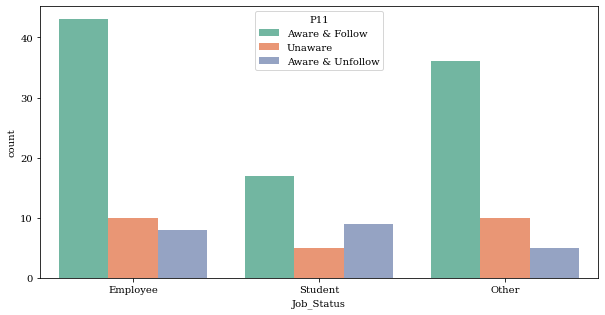

```python
categorical_summarized(SAIS, x = 'Job_Status', hue='P11')
```

```
count          143
unique           3
top       Employee
freq            61
Name: Job_Status, dtype: object
mode:  0    Employee
dtype: object
================================================================================
Employee    61
Other       51
Student     31
Name: Job_Status, dtype: int64
```

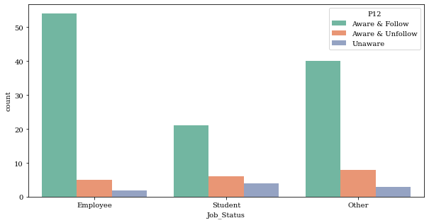

```python
categorical_summarized(SAIS, x = 'Job_Status', hue='P12')
```

```
count          143
unique           3
top       Employee
freq            61
Name: Job_Status, dtype: object
mode:  0    Employee
dtype: object
================================================================================
Employee    61
Other       51
Student     31
Name: Job_Status, dtype: int64
```

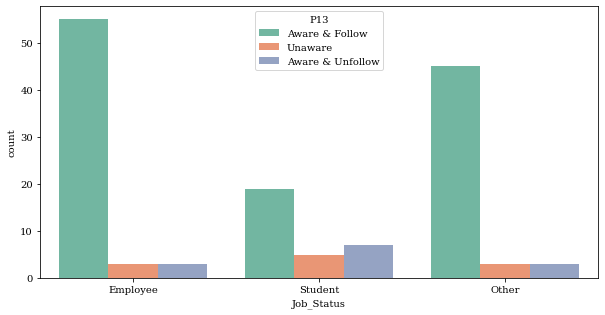

```python
categorical_summarized(SAIS, x = 'Job_Status', hue='P13')
```

```
count          143
unique           3
top       Employee
freq            61
Name: Job_Status, dtype: object
mode:  0    Employee
dtype: object
================================================================================
Employee    61
Other       51
Student     31
Name: Job_Status, dtype: int64
```

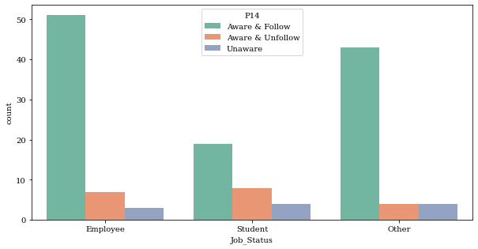

```python
categorical_summarized(SAIS, x = 'Job_Status', hue='P14')
```

```
count          143
unique           3
top       Employee
freq            61
Name: Job_Status, dtype: object
mode:  0    Employee
dtype: object
================================================================================
Employee    61
Other       51
Student     31
Name: Job_Status, dtype: int64
```

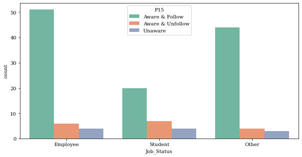

```python
categorical_summarized(SAIS, x = 'Job_Status', hue='P15')
```

```
count          143
unique           3
top       Employee
freq            61
Name: Job_Status, dtype: object
mode:  0    Employee
dtype: object
================================================================================
Employee    61
Other       51
Student     31
Name: Job_Status, dtype: int64
```

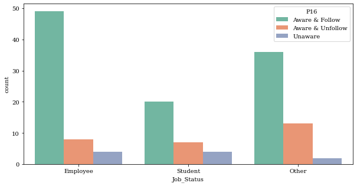

```python
categorical_summarized(SAIS, x = 'Job_Status', hue='P16')
```

```
count          143
unique           3
top       Employee
freq            61
Name: Job_Status, dtype: object
mode:  0    Employee
dtype: object
================================================================================
Employee    61
Other       51
Student     31
Name: Job_Status, dtype: int64
```

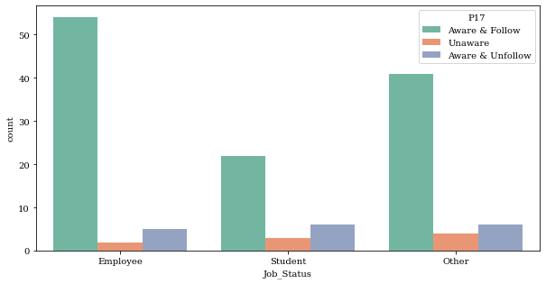

```python
categorical_summarized(SAIS, x = 'Job_Status', hue='P17')
```

```
count          143
unique           3
top       Employee
freq            61
Name: Job_Status, dtype: object
mode:  0    Employee
dtype: object
================================================================================
Employee    61
Other       51
Student     31
Name: Job_Status, dtype: int64
```

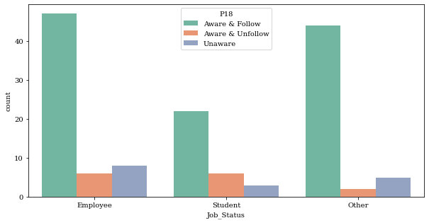

```python
categorical_summarized(SAIS, x = 'Job_Status', hue='P18')
```